# Empirical Orthogonal Functions (EOFs)

## 4.1 Eigenface

To understand what EOFs represent, we use human faces as an illustration. To begin, we first load the images to `R`:

```r
# loading csv file containing data of face images taken between
# April 1992 and April 1994 at AT&T Laboratories Cambridge
data_faces <- data.frame(read.csv("faces.csv", header=FALSE))
```

Then, we display the some of the images:

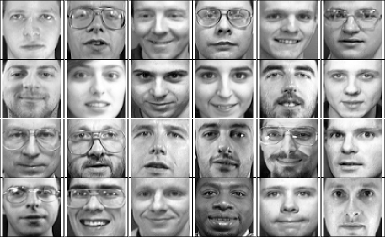

```r
par(mfrow=c(4, 6))
par(mar=c(0.05, 0.05, 0.05, 0.05))
for(i in seq(1,nrow(data_faces),10)){
  # shaping images for display
  face = matrix(as.numeric(rev(data_faces[i,])), nrow=64, byrow=FALSE)
  image(face,col=grey(seq(0, 1, length=256)), xaxt="n", yaxt="n", asp=1, useRaster=TRUE)

}
```

We can summaries the faces by averaging the images at every pixel.

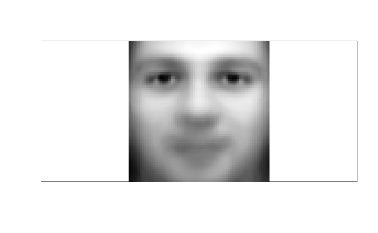

```r
# average face
avFace <- colMeans(data_faces)
face = matrix(as.numeric(rev(avFace)), nrow=64, byrow=FALSE)
image(face,col=grey(seq(0, 1, length=256)), xaxt="n", yaxt="n", asp=1, useRaster=TRUE)
```

To extract the EOF or PCA of the images, we need to center the images and then use `svd` function to obtain the EOF.

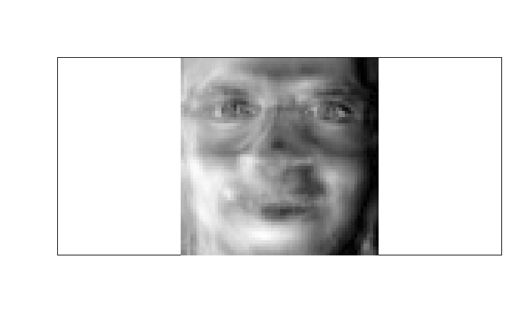

```r
# center the data
data_faces_centered <- scale(data_faces, center = TRUE, scale = FALSE)

svd <- svd(data_faces_centered) # Conduct singular value decomposition
eigVec <- svd$v[,1] # Eigenvectors of covariance matrix are equal to right singular vectors of svd

# Display first eigenvector also called eigenface ####
face <-  eigVec
face = matrix(as.numeric(rev(face )), nrow=64, byrow=FALSE)
image(abs(face),col=grey(seq(0, 1, length=256)), xaxt="n", yaxt="n", asp=1, useRaster=TRUE)
```

Since we want to find region with greatest importance, we display the absolute value of the PCA:

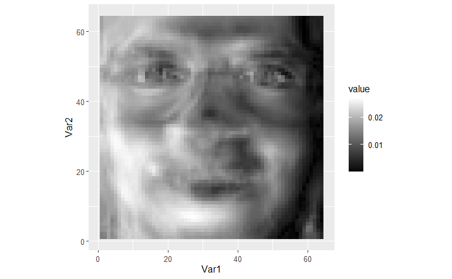

```r
library(reshape2)
library(ggplot2)

df <- melt(abs(face))
ggplot(df,aes(x=Var1,y=Var2,fill=value)) +
  geom_tile()+
  scale_fill_gradient(low="black",high="white")+
  coord_fixed()
```

We can order faces according to the PCA scores. Below are the first 10 faces based on the score.

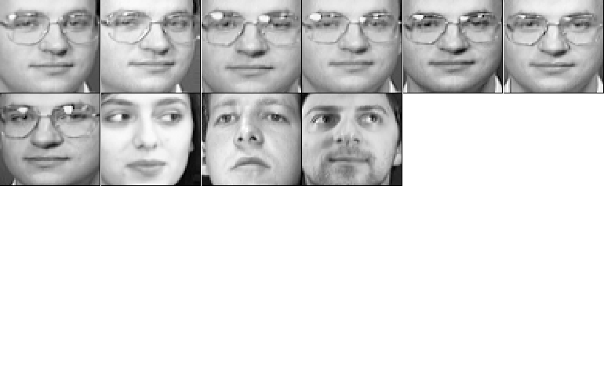

```r
# first component scores of faces
data_faces$score <- data_faces_centered %*% eigVec

library(tidyverse)
data_faces_sorted <- data_faces %>% arrange(score)
par(mfrow=c(4, 6))
par(mar=c(0.05, 0.05, 0.05, 0.05))
for(i in 1:10){
  # shaping images for display
  face = matrix(as.numeric(rev(data_faces_sorted[i,1:4096])), nrow=64, byrow=FALSE)
  image(face,col=grey(seq(0, 1, length=256)), xaxt="n", yaxt="n")

}
```

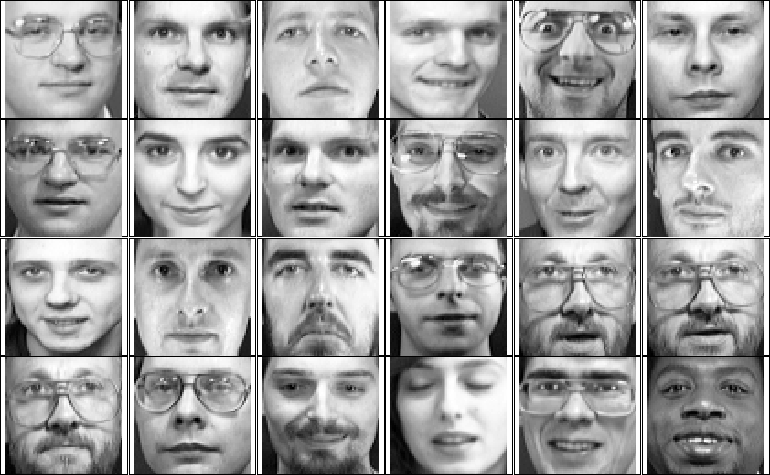

```r
par(mfrow=c(4, 6))
par(mar=c(0.05, 0.05, 0.05, 0.05))
for(i in seq(1,nrow(data_faces),10)){
  # shaping images for display
  face = matrix(as.numeric(rev(data_faces_sorted[i,1:4096])), nrow=64, byrow=FALSE)
  image(face,col=grey(seq(0, 1, length=256)), xaxt="n", yaxt="n", asp=1, useRaster=TRUE)

}
```

## 4.2 Sea Surface Temperature

We use the sea surface temperature to demostrate the use of EOFs. To begin, we visualize the data set.

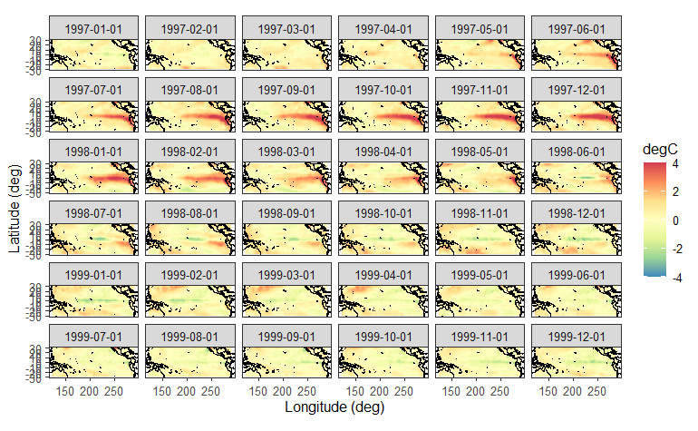

```r
library(STRbook)
library(tidyr)
library(dplyr)
library(ggplot2)

data("SSTlonlat")
data("SSTdata")

SSTdata <- cbind(SSTlonlat, SSTdata)
SST_df <- gather(SSTdata, date, sst, -lon, -lat)

date_grid <- expand.grid(Month = 1:12,
                         Year = 1970:2002,
                         stringsAsFactors = FALSE)

date_grid$date <- paste0("V", 1:396)

SST_df <- left_join(SST_df, date_grid) %>%
  select(-date)

SST_df$date <- as.Date(with(SST_df,
                         paste(Year, Month, 1, sep = "-")))

SST_df <- SST_df %>% filter(Year%in% 1997:1999 & # subset by month/year
          Month %in% 1:12)


ggplot(SST_df) + # plot points
  geom_tile(aes(lon, lat,
                fill = pmin(sst, 4))) + # clamp SST at 4deg
  facet_wrap(~date, dir = "v") + # facet by date
  fill_scale(limits = c(-4, 4), # color limits
             name = "degC") + # legend title
  geom_path(data = map_data("world2"), # add US states map
            aes(x = long, y = lat, group = group)) +
  facet_wrap(~date) +
  theme_bw() +
  xlab("Longitude (deg)") + # x-axis label
  ylab("Latitude (deg)") + # y-axis label
 coord_fixed(xlim = c(min(SST_df$lon),max(SST_df$lon)),
             ylim =c(min(SST_df$lat),max(SST_df$lat)))
```

## 4.3 Empirical Orthogonal Functions (EOFs)

Prior to carrying out an SVD, we need to put the data set into space-wide format, mean-correct it, and then standardize it.

```r
data("SSTlonlat", package = "STRbook")
data("SSTdata", package = "STRbook")

## Put data into space-wide form
Z <- t(SSTdata)
dim(Z)
```

[output not shown]

```r
## First find the matrix we need to subtract:
spat_mean <- apply(SSTdata, 1, mean)
nT <- ncol(SSTdata)
## Then subtract and standardize:
Zspat_detrend <- Z - outer(rep(1, nT), spat_mean)
Zt <- 1/sqrt(nT - 1)*Zspat_detrend
```

Finally, we extract the EOFs by `svd` function.

```r
E <- svd(Zt)
```

The SVD returns a list `E` containing the matrices $V$, $U$, and the singular values $diag(D)$. The matrix $V$ contains the EOFs in space-wide format. We change the column names of this matrix, and append the lon-lat coordinates to it as follows.

```r
V <- E$v
colnames(E$v) <- paste0("EOF", 1:ncol(SSTdata)) # label columns
EOFs <- cbind(SSTlonlat, E$v)
head(EOFs[, 1:6])
```

|  | lon | lat | EOF1 | EOF2 | EOF3 | EOF4 |
| --- | --- | --- | --- | --- | --- | --- |
| 1 | 124 | -29 | -0.0004444571 | -0.0261718690 | 0.0122865093 | 0.006234095 |
| 2 | 126 | -29 | 0.0008341521 | -0.0167297065 | 0.0108957301 | 0.006570711 |
| 3 | 128 | -29 | 0.0027146345 | -0.0067808423 | 0.0094265177 | 0.006832442 |
| 4 | 130 | -29 | 0.0045180785 | 0.0042239506 | 0.0065630719 | 0.009233298 |
| 5 | 132 | -29 | 0.0043094937 | 0.0075929699 | 0.0011062015 | 0.015090959 |
| 6 | 134 | -29 | 0.0026456615 | 0.0001549839 | 0.0006939798 | 0.017340254 |

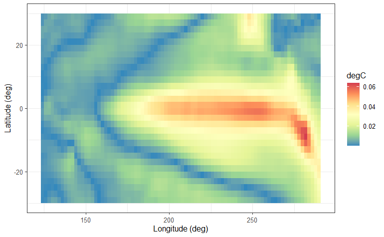

```r
ggplot(EOFs) + geom_tile(aes(x = lon, y = lat, fill = abs(EOF1))) +
fill_scale(name = "degC") + theme_bw() +
xlab("Longitude (deg)") + ylab("Latitude (deg)")
```

## 4.4 Spatial Point Pattern

An example of spatial point pattern is given by the `swedishpines` data from `spatstat`. This pattern represents the locations of 71 trees in a Swedish forest plot of $9.6 × 10$ meters

```r
library(spatstat)
data(swedishpines)
X <- swedishpines
plot(X)
axis(1)
```

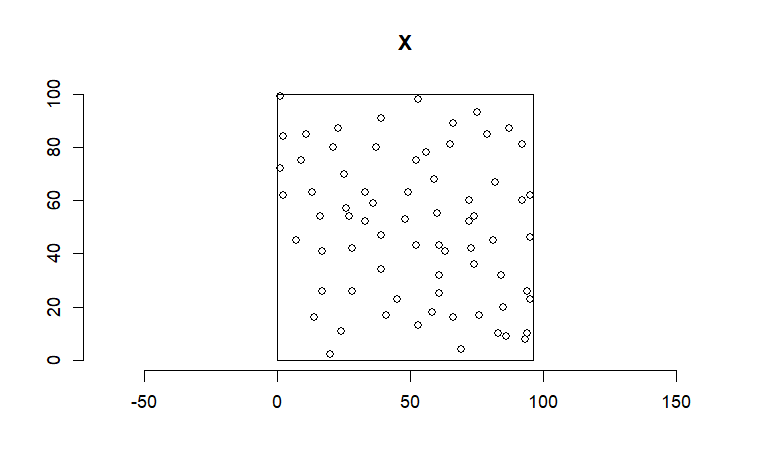

```r
axis(2)
```

```r
summary(X)
```

```
Planar point pattern:  71 points
Average intensity 0.007395833 points per square unit (one unit = 0.1 metres)

Coordinates are integers
i.e. rounded to the nearest unit (one unit = 0.1 metres)

Window: rectangle = [0, 96] x [0, 100] units
Window area = 9600 square units
Unit of length: 0.1 metres
```

To get an impression of the spatial point pattern, we can calculate the intensity of events, which indicates the mean number of events per unit area. The `density()` function of the `spatstat` package can be used to compute a kernel smoothed intensity function from a point pattern. This function has an argument called `sigma` which refers to the smoothing bandwidth, the standard deviation of the smoothing kernel.

In the `swedishpines` data, the coordinates of the point pattern are expressed in decimeters (0.1 meter). Here, we use `density()` with `sigma = 10` so the smoothing bandwidth is 10 decimeters or 1 meter. Figure 17.1 shows the estimated intensity. We observe that the intensity varies across the region, and the average intensity is equal to 0.0074 trees per square decimeter, that is, 0.74 trees per square meter.

```r
# density() calls density.ppp() if the argument is a ppp object
den <- density(x = X, sigma = 10)
summary(den)
```

```
real-valued pixel image
128 x 128 pixel array (ny, nx)
enclosing rectangle: [0, 96] x [0, 100] units (one unit = 0.1 metres)
dimensions of each pixel: 0.75 x 0.78125 units
(one unit = 0.1 metres)
Image is defined on the full rectangular grid
Frame area = 9600 square units
Pixel values
    range = [0.001841662, 0.0156937]
    integral = 71.01604
    mean = 0.007397504
```

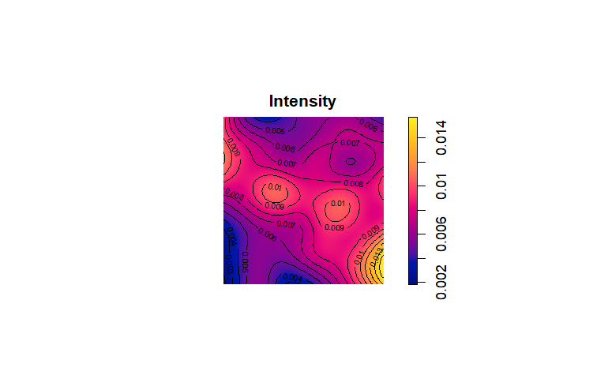

```r
plot(den, main = "Intensity")
contour(den, add = TRUE) # contourplot
```

## 4.5 Creating Spatial Point Patterns

In `spatstat`, spatial point patterns are represented as objects of class `ppp` (planar point pattern). To create a `ppp` object, we use the `ppp()` function passing the vectors `x` and `y` with the event coordinates, and the observation window which is of class `owin`.

For example, here we create a spatial point pattern of 100 randomly generated points in the region $[0, 1] × [0, 2]$. First, we use the `owin()` function to create an object of class `owin` with the observation window $[0, 1] × [0, 2]$ passing the ranges of the horizontal and vertical axes.

```r
library(spatstat)
win <- owin(xrange = c(0, 1), yrange = c(0, 2))
```

Then, we simulate 100 random points in the observation window $[0, 1] × [0, 2]$.

```r
x <- runif(100, 0, 1)
y <- runif(100, 0, 2)
```

Finally, we create the `ppp` object with the `ppp()` function passing the `x` and `y` coordinates of the events, and the `owin` object with the window.

```r
X <- ppp(x = x, y = y, window = win)
X
```

```
Planar point pattern: 100 points
window: rectangle = [0, 1] x [0, 2] units
```

```r
plot(X)
axis(1)
```

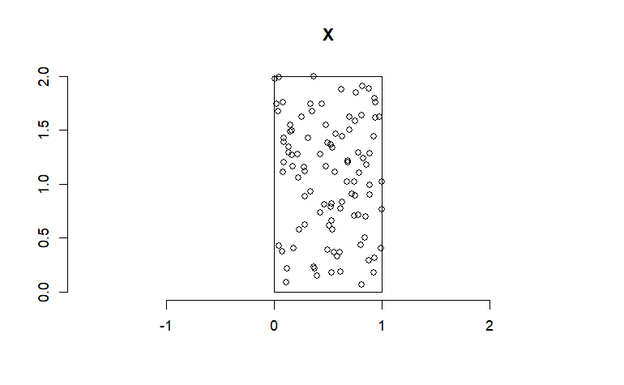

```r
axis(2)
```

Marks denoting associated information of events can be set with `marks()`:

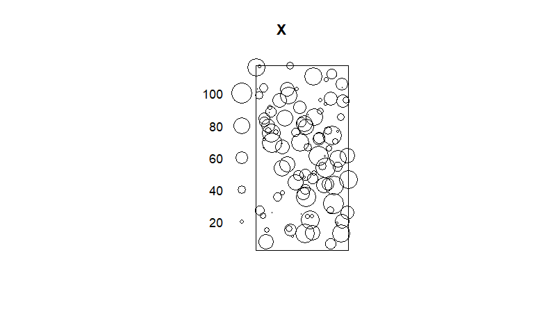

```r
marks(X) <- 1:npoints(X)
plot(X)
```

In case we wish to use a polygon of class `sf` as observation window, we can use `as.owin()` to transform the `sf` object to an `owin` object.

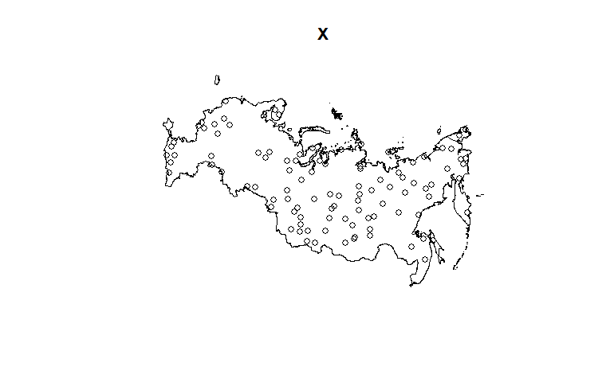

```r
library(rnaturalearth)
library(sf)
map <- ne_countries(type = "countries", country = "Russia",
                    scale = "large", returnclass = "sf")
map <- st_transform(map, crs = "EPSG:32650")
win <- as.owin(map)
X <- runifpoint(100, win = win)
plot(X)
```

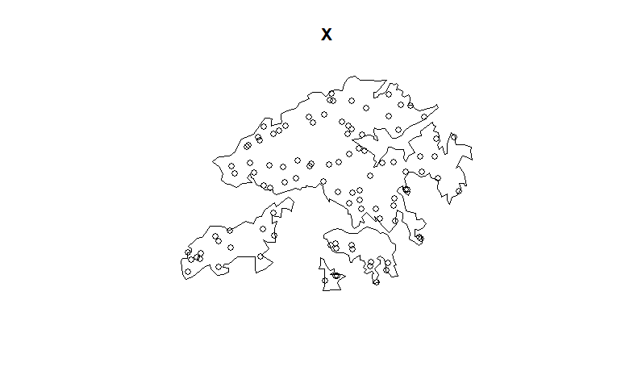

```r
library(rnaturalearth)
library(sf)
# 1. Fetch Hong Kong's boundaries specifically
map <- ne_countries(type = "map_units", country = "Hong Kong S.A.R.",
                    scale = "large", returnclass = "sf")

# 2. Transform to the flat HK1980 Grid projection (measured in meters)
map <- st_transform(map, crs = "EPSG:2326")
win <- as.owin(map)
X <- runifpoint(100, win = win)
plot(X)
```

## 4.6 Spatial Point Processes and Simulation

The `rpoispp()` function accepts an argument `lambda` that indicates the intensity of the Poisson process. `lambda` can be a single positive number, function,or pixel image. The argument `win` of `rpoispp()` is the observation window in which to simulate the pattern. `win` can be an object of class `owin` or an object acceptable to `as.owin()`.

```r
library(spatstat)
phom <- rpoispp(lambda = 100,
win = owin(xrange = c(0, 1), yrange = c(0, 2)))
phom$n
```

```
[1] 203
```

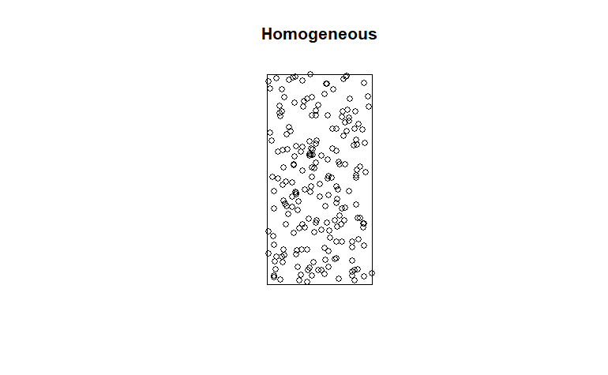

```r
plot(phom, main = "Homogeneous")
```

```r
# intensityfunction
lambda <- function(x){return(10 + 100 * x[1] + 200 * x[2])}

# grid
xseq <- seq(0, 1, length.out = 50)
yseq <- seq(0, 2, length.out = 100)
grid <- expand.grid(xseq, yseq)

# evaluation of the function on a grid
z <- apply(grid, 1, lambda)
```

```r
fnintensity <- function(x, y){return(10 + 100 * x + 200 * y)}
pinhom <- rpoispp(lambda = fnintensity,
                  win = owin(xrange = c(0, 1), yrange = c(0, 2)))
pinhom$n
```

```
[1] 522
```

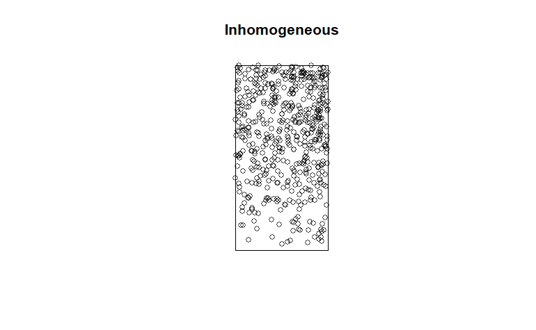

```r
plot(pinhom, main = "Inhomogeneous")
```

```r
# 1. Automatically calculate the optimal bandwidth via Likelihood CV
opt_bw_ppl <- bw.ppl(pinhom)
print(opt_bw_ppl)
```

```
    sigma
0.1835485
```

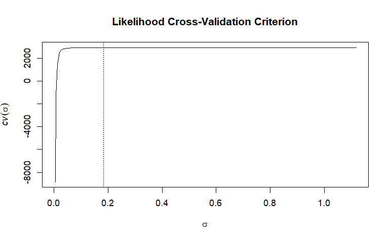

```r
# 2. View the cross-validation curve to check for a clear minimum point
plot(opt_bw_ppl, main = "Likelihood Cross-Validation Criterion")
```

```r
# density() calls density.ppp() if the argument is a ppp object
opt_bw_ppl
```

```
    sigma
0.1835485
```

```r
den <- density(x = pinhom, sigma = opt_bw_ppl)
summary(den)
```

```
real-valued pixel image
128 x 128 pixel array (ny, nx)
enclosing rectangle: [0, 1] x [0, 2] units
dimensions of each pixel: 0.00781 x 0.015625 units
Image is defined on the full rectangular grid
Frame area = 2 square units
Pixel values
    range = [40.41868, 522.9375]
    integral = 517.5135
    mean = 258.7567
```

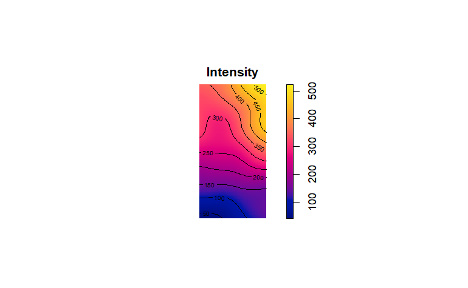

```r
plot(den, main = "Intensity")
contour(den, add = TRUE) # contourplot
```

## 4.7 Testing CSR with the `quadrat` Method

We use the `swedishpines` data of `spatstat` which`represents`the positions`of 71 trees in a Swedish forest plot.

```r
library(spatstat)
data(swedishpines)
X <- swedishpines
X
```

```
Planar point pattern: 71 points
window: rectangle = [0, 96] x [0, 100] units (one unit = 0.1 metres)
```

The `quadratcount()` function of `spatstat` divides the window containing the point pattern into $nx × ny$ grid rectangular tiles or quadrats of equal size, and counts the number of points in each quadrat. If the window is not a rectangle, quadrats are intersected with the window. The arguments of the `quadratcount()` function include `X`, the point pattern of class `ppp`, and `nx` and `ny` which denote the numbers of rectangular quadrats in the `x` and `y` directions.

```r
Q <- quadratcount(X, nx = 4, ny = 3)
Q
```

```
             x
y             [0,24] (24,48] (48,72] (72,96]
  (66.7,100]       7       3       6       5
  (33.3,66.7]      5       9       7       7
  [0,33.3]         4       3       6       9
```

```r
plot(X)
axis(1)
```

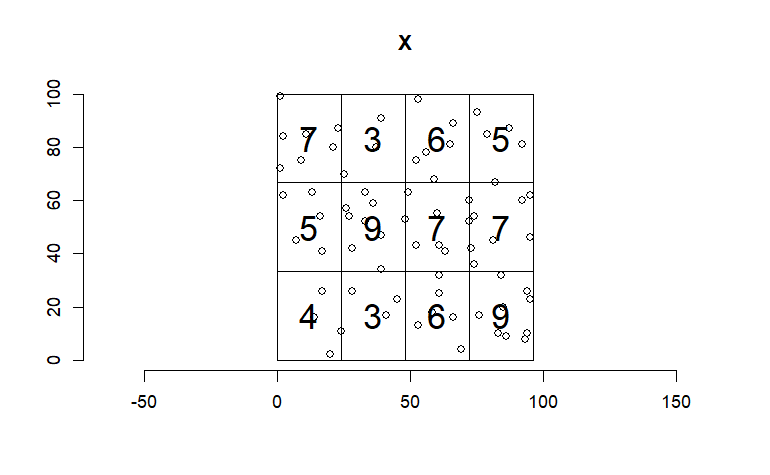

```r
axis(2)
plot(Q, add = TRUE, cex = 2)
```

By default, `quadrat.test()` assesses significance by comparing the observed test statistic with the chi-squared distribution (`method ="Chisq"`) but can also perform Monte Carlo based tests with `method ="MonteCarlo"`.

```r
quadrat.test(Q, method="MonteCarlo")
```

```
    Conditional Monte Carlo test of CSR using quadrat counts
    Test statistic: Pearson X2 statistic

data:
X2 = 7.5915, p-value = 0.504
alternative hypothesis: two.sided

Quadrats: 4 by 3 grid of tiles
```